# Activity: Area Data II

# Activity: Area Data II

Remember, you can download the source file for this activity from [here](https://github.com/paezha/Spatial-Statistics-Course).

## Practice questions

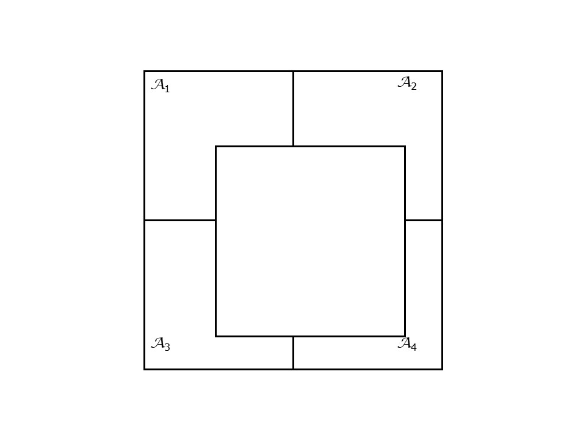

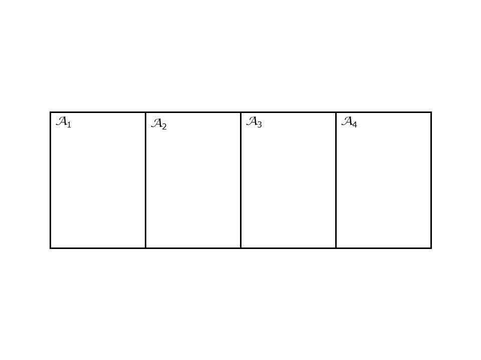

## Learning objectives

In this activity, you will:

1. Create spatial weights matrices.
2. Calculate the spatial moving average of a variable.
3. Create scatterplots of a variable and its spatial moving average.
4. Think about ways to decide whether a landscape is random when working with area data.

## Suggested reading

O’Sullivan D and Unwin D (2010) Geographic Information Analysis, 2nd Edition, Chapter 7. John Wiley & Sons: New Jersey.

## Preliminaries

For this activity you will need the following:

- An R markdown notebook version of this document (the source file).
- A package called `geog4ga3`.

It is good practice to clear the working space to make sure that you do not have extraneous items there when you begin your work. The command in R to clear the workspace is `rm` (for “remove”), followed by a list of items to be removed. To clear the workspace from *all* objects, do the following:

```r
rm(list = ls())
```

Note that `ls()` lists all objects currently on the worspace.

Load the libraries you will use in this activity.

In addition to `tidyverse`, you will need `sf`, a package that implements simple features in R (you can learn about `sf` [here](https://cran.r-project.org/web/packages/sf/vignettes/sf1.html)) and `spdep`, a package that implements several spatial statistical methods (you can learn more about it [here](https://cran.r-project.org/web/packages/spdep/index.html)):

```r
library(tidyverse)
library(spdep)
library(sf)
library(geog4ga3)
library(plotly)
```

In the practice that preceded this activity, you learned about the area data and visualization techniques for area data.

Begin by loading the data that you will use in this activity:

```r
data(Hamilton_CT)
```

This is a `sf` object with census tracts and selected demographic variables for the Hamilton CMA in Canada.

You can obtain new (calculated) variables as follows. For instance, to obtain the proportion of residents who are between 20 and 34 years old, and between 35 and 49:

```r
Hamilton_CT <- mutate(Hamilton_CT, Prop20to34 = (AGE_20_TO_24 + AGE_25_TO_29 + AGE_30_TO_34)/POPULATION, Prop35to49 = (AGE_35_TO_39 + AGE_40_TO_44 + AGE_45_TO_49)/POPULATION)
```

You can also convert the `sf` object into a `SpatialPolygonsDataFrame` object for use with the `spdedp` package:

```r
Hamilton_CT.sp <- as(Hamilton_CT, "Spatial")
```

You are now ready for the next activity.

## Activity

1. Create a spatial weights matrix for the census tracts in the Hamilton CMA.

```r
Hamilton_CT.nb <- poly2nb(pl = Hamilton_CT.sp, queen = TRUE)
Hamilton_CT$TRACT[Hamilton_CT.nb[[1]]]
```

```
[1] "5370120.02" "5370122.01" "5370122.02" "5370124.00" "5370142.01" "5370133.01" "5370130.03"
```

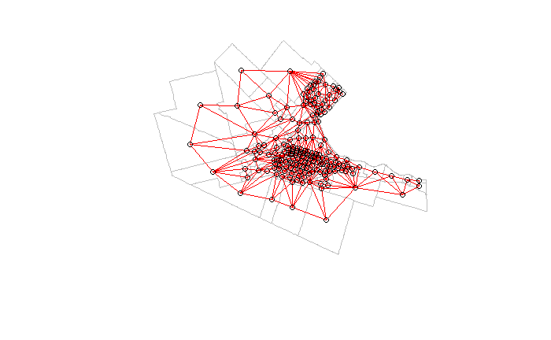

```r
Hamilton_CT.w <- nb2listw(Hamilton_CT.nb)
plot(Hamilton_CT.sp, border = "gray")
plot(Hamilton_CT.nb, coordinates(Hamilton_CT.sp), col = "red", add = TRUE)
```

```r
AGE20to34.sma <- lag.listw(x = Hamilton_CT.w, Hamilton_CT$AGE_20_TO_24 + Hamilton_CT$AGE_25_TO_29 + Hamilton_CT$AGE_30_TO_34)
AGE35to49.sma <- lag.listw(x = Hamilton_CT.w, Hamilton_CT$AGE_35_TO_39 + Hamilton_CT$AGE_40_TO_44 + Hamilton_CT$AGE_45_TO_49)
AGE50to65.sma <- lag.listw(x = Hamilton_CT.w, Hamilton_CT$AGE_50_TO_54 + Hamilton_CT$AGE_55_TO_59 + Hamilton_CT$AGE_60_TO_64)
age65andolder.sma <- lag.listw(x = Hamilton_CT.w, Hamilton_CT$AGE_65_TO_69 + Hamilton_CT$AGE_70_TO_74 + Hamilton_CT$AGE_75_TO_79 + Hamilton_CT$AGE_80_TO_84 + Hamilton_CT$AGE_MORE_85)
```

3. Append the spatial moving averages to your dataframe.

```r
Hamilton_CT <- left_join(Hamilton_CT, data.frame(TRACT = Hamilton_CT$TRACT, AGE20to34.sma, AGE35to49.sma, AGE50to65.sma))
```

```
Column `TRACT` joining character vector and factor, coercing into character vector
```

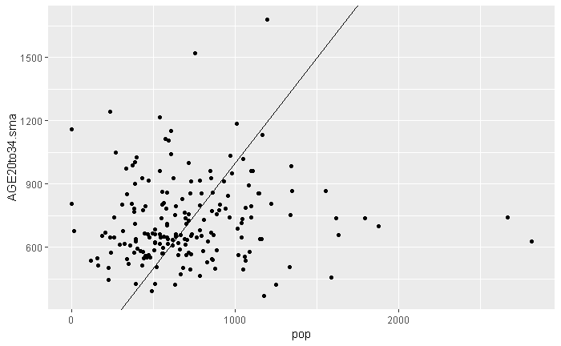

```r
pop <- (Hamilton_CT$AGE_20_TO_24 + Hamilton_CT$AGE_25_TO_29 + Hamilton_CT$AGE_30_TO_34)
pop2 <- (Hamilton_CT$AGE_35_TO_39 + Hamilton_CT$AGE_40_TO_44 + Hamilton_CT$AGE_45_TO_49)
ggplot(Hamilton_CT, aes(y = AGE20to34.sma, x = pop)) + geom_point() + geom_abline(slope = 1, intercept = 0)
```

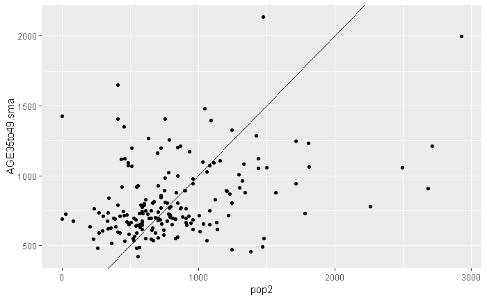

```r
ggplot(Hamilton_CT, aes(y = AGE35to49.sma, x = pop2)) + geom_point() + geom_abline(slope = 1, intercept = 0)
```

NOTE: Looking at the plot generated above, when the points generated are flat, meaning they run horizontally across the graph, the data is random becasue the neighbours are all over the study area and there is no apparent pattern whereas when the data is non-random, the points will follow the line meaning there is a pattern across the study area.

5. What would you expect the scatterplots of the variables and their spatial moving averages to look like if the variable was spatially random? Discuss.